# PCA vs. PLS with no and few discriminating variables

Eric R. Scott

```r
library(chemhelper) #for sim_*(), plot_pca(), plot_plsda(), get_VIP(), and get_loadings()
library(tidyverse)
library(ropls) #for opls(), which does pca and pls-da
library(cowplot) #for plot_grid()
theme_set(theme_gray())
library(iheatmapr) #for correlation heatmaps
```

# No discriminating variables

The code chunk below creates a data frame with a grouping variable with two groups (a and b) with n=10 per group, 5 variables that don’t covary, and two groups of 10 variables that moderately covary.

```r
# myseed <- runif(1, 0, 1000)
myseed <- 401.6368
df <- data_frame(group = rep(c("a", "b"), each = 10))
no_discr <- df %>%
  sim_covar(5, var = 1, cov = 0, name = "uncorr", seed = myseed) %>%
  sim_covar(10, var = 1, cov = 0.55, name = "corrA", seed = myseed + 1) %>%
  sim_covar(10, var = 1, cov = 0.55, name = "corrB", seed = myseed + 2)
```

This heatmap shows the correlation structure.

```r
no_discr %>%
  select(-group) %>%
  cor() %>%
  iheatmap(row_labels = TRUE, col_labels = TRUE, name = "cor")
```

[interactive chart not shown]

```r
no_discr.cor <- no_discr %>%
  select(-group) %>%
  cor() %>%
  as.data.frame() %>%
  rownames_to_column(var = "row") %>%
  gather(-row, key = col, value = cor)
cor1 <- ggplot(no_discr.cor, aes(x = col, y = row, fill = cor)) +
  geom_tile() +
  scale_fill_gradient2("Correlation Coeficient") +
  labs(x = NULL, y = NULL) +
  theme_minimal() +
  theme(axis.text.x = element_text(angle = 90), legend.position = "top")
```

Then I perform PCA and PLS-DA on this dataset, forcing both models to have two axes (for plotting). The PCA score plot shows no separation and the first two axes explain more than half of the variation in the data. The PLS-DA score plot shows slight separation of the groups (even though there is none). It’s a pretty terrible model with a negative Q<sup>2</sup> value and a low R<sup>2</sup> value.

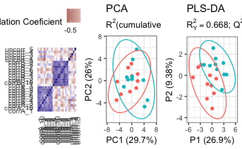

```r
pca1.plot <- plot_pca(pca1, no_discr$group, annotate = "subtitle")
pls1.plot <- plot_plsda(pls1, annotate = "subtitle")
plot_grid(cor1,
          pca1.plot + theme(legend.position = "NULL"),
          pls1.plot + theme(legend.position = "NULL"), nrow = 1, ncol = 3)
```

# Few discriminating variables

Keeping the total number of observations and variables the same, and using the same random seed, I create a second data set with 5 variables that do not covary within groups, but differ in their means between groups.

```r
discr <- df %>%
  sim_covar(5, var = 1, cov = 0, name = "uncorr", seed = myseed) %>%
  sim_covar(8, var = 1, cov = 0.55, name = "corrA", seed = myseed + 1) %>%
  sim_covar(7, var = 1, cov = 0.55, name = "corrB", seed = myseed + 2) %>%
  sim_discr(5, var = 1, cov = 0, group_means = c(-1, 1), name = "discr", seed = myseed + 3)
```

```r
discr %>%
  select(-group) %>%
  cor() %>%
  iheatmap(row_labels = TRUE, col_labels = TRUE, name = "cor")
```

[interactive chart not shown]

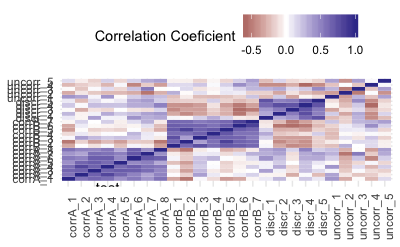

```r
discr.cor <- discr %>%
  select(-group) %>%
  cor() %>%
  as.data.frame() %>%
  rownames_to_column(var = "row") %>%
  gather(-row, key = col, value = cor)
cor2 <- ggplot(discr.cor, aes(x = col, y = row, fill = cor)) +
  geom_tile() +
  scale_fill_gradient2("Correlation Coeficient") +
  labs(x = NULL, y = NULL) +
  theme_minimal() +
  theme(axis.text.x = element_text(angle = 90), legend.position = "top") +
  annotate(geom = "text", x = 4, y = -1, label = "test")
cor2
```

The PCA score plot still shows no real separation because the discriminating variables do not contribute much to the total covariation in the data. The PLS-DA plot shows very strong separation, despite the differences between the groups being only due to 5 out of 25 variables. The PLS-DA model performs well, with high R<sup>2</sup> and Q<sup>2</sup> values

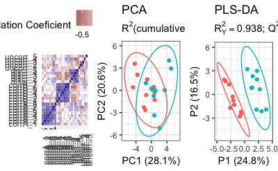

```r
pca2.plot <- plot_pca(pca2, discr$group, annotate = "subtitle")
pls2.plot <- plot_plsda(pls2, annotate = "subtitle")
plot_grid(cor2, pca2.plot + theme(legend.position = "NULL"),
          pls2.plot + theme(legend.position = "NULL"), nrow = 1, ncol = 3)
```

```r
get_VIP(pls2) %>%
  arrange(desc(VIP))
```

| Variable | VIP |
| --- | --- |
| discr_5 | 1.90622668 |
| discr_4 | 1.87250467 |
| discr_1 | 1.80759059 |
| discr_2 | 1.52239173 |
| discr_3 | 1.44525624 |
| uncorr_4 | 1.15325045 |
| corrA_8 | 1.10084718 |
| corrA_6 | 0.92393216 |
| corrA_7 | 0.89366342 |
| uncorr_3 | 0.83370908 |

[output cut: 15 more lines]

```r
get_loadings(pca2) %>%
  select(Variable, p1, p2) %>%
  arrange(desc(abs(p1)))
```

| Variable | p1 | p2 |
| --- | --- | --- |
| discr_4 | 0.28751591 | 0.066892779 |
| corrB_2 | -0.27610082 | -0.131805524 |
| corrA_8 | 0.26674900 | -0.141319966 |
| discr_2 | 0.26237131 | 0.054716419 |
| corrB_6 | -0.25071797 | -0.266743841 |
| corrB_5 | -0.24361280 | -0.207358155 |
| corrA_1 | 0.24356946 | -0.155129591 |
| corrB_1 | -0.24183601 | -0.220760328 |
| corrA_6 | 0.21292609 | -0.290692819 |
| corrA_7 | 0.20517304 | -0.267602915 |

[output cut: 15 more lines]

# Save plots and tables

```r
fig1 <- plot_grid(cor1,
          pca1.plot + theme(legend.position = "NULL") + labs(title = ""),
          pls1.plot + theme(legend.position = "NULL") + labs(title = ""),
          cor2,
          pca2.plot + theme(legend.position = "NULL") + labs(title = ""),
          pls2.plot + theme(legend.position = "NULL") + labs(title = ""),
          ncol = 3, nrow = 2, labels = "AUTO")
save_plot("figs/fig1.png", fig1, ncol = 3, nrow = 2)
```

| Variable | PLS-DA VIP score | PC1 loading | PC2 loading |
| --- | --- | --- | --- |
| corrA_1 | 0.6431 | 0.2436 | -0.1551 |
| corrA_2 | 0.4015 | 0.1245 | -0.2846 |
| corrA_3 | 0.6317 | 0.2038 | -0.2464 |
| corrA_4 | 0.5765 | 0.2043 | -0.2833 |
| corrA_5 | 0.4832 | 0.1793 | -0.1914 |
| corrA_6 | 0.9239 | 0.2129 | -0.2907 |
| corrA_7 | 0.8937 | 0.2052 | -0.2676 |
| corrA_8 | 1.1008 | 0.2667 | -0.1413 |
| corrB_1 | 0.6465 | -0.2418 | -0.2208 |
| corrB_2 | 0.7172 | -0.2761 | -0.1318 |

[output cut: 15 more lines]